# STA232B Project 2

Eric Kalosa-Kenyon

11 February 2018

Abstract

In this project, I interrogate the random sire effects on lamb weight from the Harville & French 1985 model.

# Introduction

Central to this report is the following linear mixed model:
$$y_{ijkd} = \mu + \delta_i + \pi_j + s_{jk} + e_{ijkd}$$
Harville & French proposed this model in 1985 to assess the effects of age and lineage on lamb weight. $\mu, \delta_i, \textrm{ and } \pi_j$ are fixed effects, and $s_{jk}$ is a random effect. $e_{ijkd}$ is additional error. The random effect is $s_{jk}\sim N(0,G)$ and the error is $e_{ijdk}\sim N(0,R)$. The fixed effects are age and line ($\delta \textrm{ and } \pi$) and the random effect accounts for the sire ($s$).

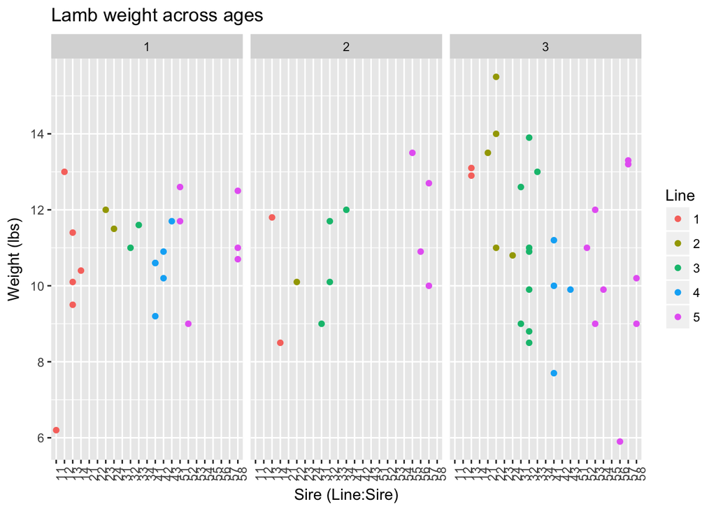

Notice that the data are unbalanced and there are missing observations for some combinations of factors (e.g. Age 2 and Line 4).

# Fitting the LMM using ML and REML

```r
## Fit the LMM using both ML and REML

ff = Weight ~ Line + Age + (1 | Sire)
ml_lmm = lmer(formula = ff, data = lamb, REML = F)
reml_lmm = lmer(formula = ff, data = lamb, REML = T)

FIX_reml = fixef(reml_lmm)
RAN_reml = ranef(reml_lmm)$Sire$`(Intercept)`
FIX_ml = fixef(ml_lmm)
RAN_ml = ranef(ml_lmm)$Sire$`(Intercept)`

ml_lmm_nlme = lme(
             fixed = Weight ~ Line + Age,
             random = ~ 1 | Sire,
             data = lamb,
             method = "ML"
            )
reml_lmm_nlme = lme(
             fixed = Weight ~ Line + Age - 1,
             random = ~ 1 | Sire,
             data = lamb,
             method = "REML"
            )
```

The variance of the random effects ($s$) for the model fit using maximum likelihood (ML) is $\hat{\sigma}_{ML}^{(s)} = 2.0877546\times 10^{-16}$ and that of the restricted maximum likelihood (REML) fit is $\hat{\sigma}_{REML}^{(s)} = 0.1084728$.

## Sorting sire quality by random effect

| Rank | ML | REML |
| --- | --- | --- |
| 1 | 56 | 56 |
| 2 | 11 | 11 |
| 3 | 14 | 24 |
| 4 | 24 | 31 |
| 5 | 32 | 14 |
| 6 | 31 | 52 |
| 7 | 52 | 32 |
| 8 | 41 | 41 |
| 9 | 58 | 54 |
| 10 | 54 | 58 |

The ranking of sires by their EBLUP random effects measures the quality of each ram. That is, the more positive effect a ram has on the lamb’s weight, the more desirable that ram is as a sire. Using the `lme4` package (not shown), the ML random effects EBLUP calculations suffer from underflow - alternatively, using the `nlme` package as in the table above, the ML and REML estimated rankings appear to agree for the first couple rams, but past that, the rankings diverge. Here it becomes important to clarify that the REML estimates are more accurate - in a situation similar to the Neyman Scott problem, the ML EBLUP using $\hat{\sigma}_{ML}^{(s)}$ is not consistent, and in fact far underestimates the variance introduced by the random effect. A brief sanity check is possible using the exploratory graph presented in the introduction.

# Line-wise means

The line-wise mean EBLUP is defined as follows:
$$\mathcal{L}_i =
E[\frac{1}{N_i}\sum_{i=1}^{n_i}\sum_{j=1}^{n_{ij}} y_{ijk} \mid s]$$

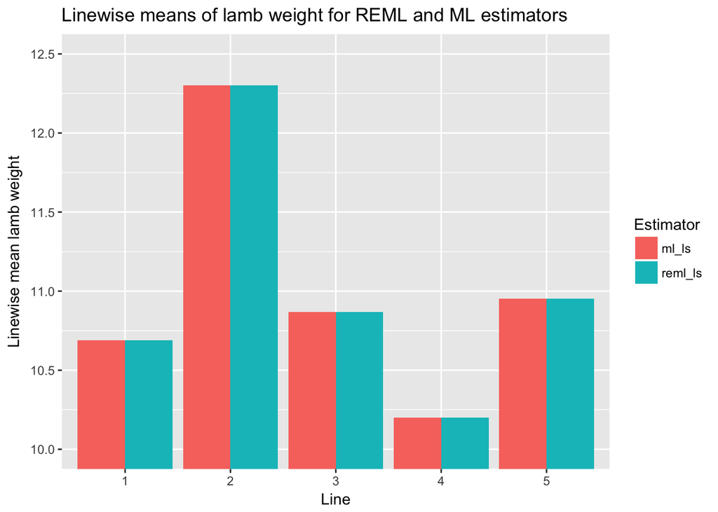

The linewise means $\hat{\mathcal{L}_i}$ are calculated in the analysis script included in the final section of this report. Following those calculations, the lines are ranked as $4, 1, 3, 5, 2$. Note that the linewise means are identical for the ML and REML estimators. This identity is due to the fact that REML and ML estimations for BLUE’s are identical - the restriction in REML is used for calculating random effect BLUP’s.

## Estimating margin of error for sire effects using jackknife

Following the lecture notes (presumably also replicated in Jiang 2007), the mean squared prediction errors for each of the random sire effects is calculated as follows:

$$mspe(\hat{s_{ij}}) = b_{ij}(\hat{\theta}) -
\frac{m-1}{m}\sum_{kl}(b_{ij}(\hat{\theta}_{-kl}) - b_{ij}(\hat{\theta})) +
\frac{m-1}{m}\sum_{kl}(
\hat{s}_{ij}(\hat{\theta}_{-kl}) - \hat{s}_{ij}(\hat{\theta})
)^2$$

where
$$b_{ij}(\hat{\theta}) =
\frac{\hat{\sigma}_e^2 \hat{\sigma}_s^2}
{\hat{\sigma}_e^2 + n_{ij}\hat{\sigma}_s^2}$$

$n_{ij}$ is the number of measurements from sire $s_{ij}$, and $\cdot_{-ij}$ is the calculation performed without the measurements taken from sire $s_{ij}$. The following plot depicts the random effects $s_{ij}$ with error bars corresponding to the modified jackknifed MSPE’s.

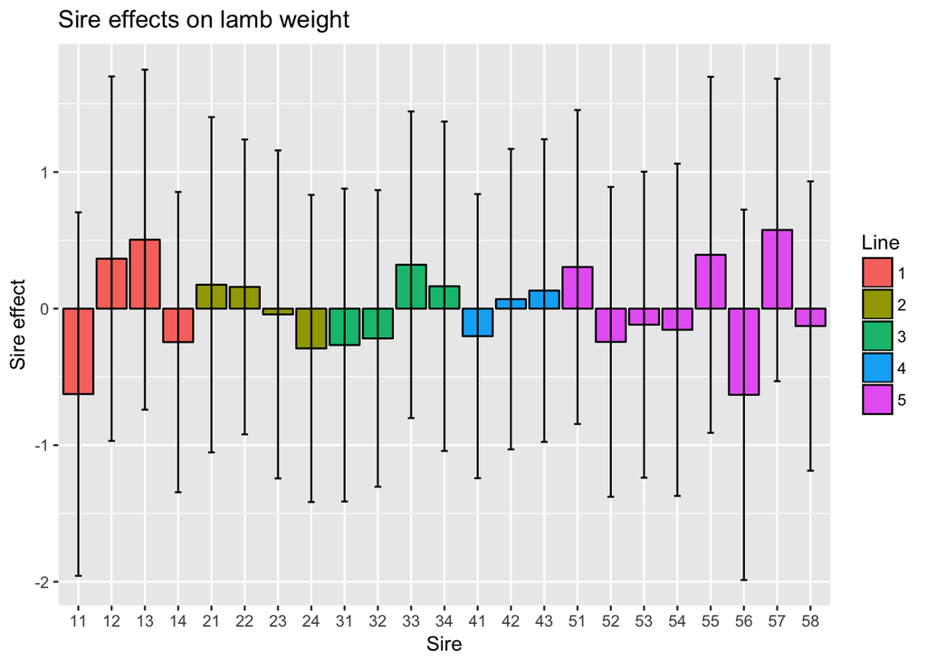

As is shown in the plot, none of the sire effects are all that significant. Following this result, more replicates are needed to make decisions confidently regarding the rankings of sires. Practically, at this point, all decisions should me made based on line-wise means $\mathcal{L}_i$.

# Appendix

In this section I present the data and source code used to generate this report.

## Source Code

```
# Author: Eric Kalosa-Kenyon, Chi Po Choi

## @knitr setup
rm(list=ls())
library(nlme) # fitting lmm
library(lme4) # fitting lmm
library(ggplot2) # plotting
library(reshape)

lamb = read.csv(file = "observations.csv")
lamb$Sire = factor(lamb$Sire)
lamb$Line = factor(lamb$Line)
lamb$Age  = factor(lamb$Age)

## @knitr fit
## Fit the LMM using both ML and REML

ff = Weight ~ Line + Age + (1 | Sire)
ml_lmm = lmer(formula = ff, data = lamb, REML = F)
reml_lmm = lmer(formula = ff, data = lamb, REML = T)

FIX_reml = fixef(reml_lmm)
RAN_reml = ranef(reml_lmm)$Sire$`(Intercept)`
FIX_ml = fixef(ml_lmm)
RAN_ml = ranef(ml_lmm)$Sire$`(Intercept)`

ml_lmm_nlme = lme(
             fixed = Weight ~ Line + Age,
             random = ~ 1 | Sire,
             data = lamb,
             method = "ML"
            )
reml_lmm_nlme = lme(
             fixed = Weight ~ Line + Age - 1,
             random = ~ 1 | Sire,
             data = lamb,
             method = "REML"
            )

## @knitr old_code
```

[output cut: 120 more lines]

```
    write.csv(jack, "jack.csv")
}
}else{
    jack = read.csv("jack.csv")
}

# plot the line effects with sqrt(mspe) errorbars
reml_ref$err = sqrt(jack$mspe)
reml_ref$sire = rownames(reml_ref)
reml_ref$Line = substring(reml_ref$sire,1,1)
p3 = ggplot(reml_ref, aes(x=sire, y=ref, fill=Line)) +
    geom_bar(stat="identity", color="black") +
    geom_errorbar(aes(ymin=ref-err, ymax=ref+err), width=.2) +
    labs(title="Sire effects on lamb weight",
         x="Sire", y="Sire effect")
```

## Data

Harville and French lamb weight observations (1985):

| Weight | Sire | Line | Age |
| --- | --- | --- | --- |
| 6.2 | 11 | 1 | 1 |
| 13.0 | 12 | 1 | 1 |
| 9.5 | 13 | 1 | 1 |
| 10.1 | 13 | 1 | 1 |
| 11.4 | 13 | 1 | 1 |
| 11.8 | 13 | 1 | 2 |
| 12.9 | 13 | 1 | 3 |
| 13.1 | 13 | 1 | 3 |
| 10.4 | 14 | 1 | 1 |
| 8.5 | 14 | 1 | 2 |
| 13.5 | 21 | 2 | 3 |
| 10.1 | 22 | 2 | 2 |
| 11.0 | 22 | 2 | 3 |
| 14.0 | 22 | 2 | 3 |
| 15.5 | 22 | 2 | 3 |
| 12.0 | 23 | 2 | 1 |
| 11.5 | 24 | 2 | 1 |
| 10.8 | 24 | 2 | 3 |
| 9.0 | 31 | 3 | 2 |
| 9.0 | 31 | 3 | 3 |
| 12.6 | 31 | 3 | 3 |
| 11.0 | 32 | 3 | 1 |
| 10.1 | 32 | 3 | 2 |
| 11.7 | 32 | 3 | 2 |
| 8.5 | 32 | 3 | 3 |
| 8.8 | 32 | 3 | 3 |
| 9.9 | 32 | 3 | 3 |
| 10.9 | 32 | 3 | 3 |
| 11.0 | 32 | 3 | 3 |
| 13.9 | 32 | 3 | 3 |
| 11.6 | 33 | 3 | 1 |
| 13.0 | 33 | 3 | 3 |
| 12.0 | 34 | 3 | 2 |
| 9.2 | 41 | 4 | 1 |
| 10.6 | 41 | 4 | 1 |
| 10.6 | 41 | 4 | 1 |
| 7.7 | 41 | 4 | 3 |
| 10.0 | 41 | 4 | 3 |
| 11.2 | 41 | 4 | 3 |
| 10.2 | 42 | 4 | 1 |
| 10.9 | 42 | 4 | 1 |
| 11.7 | 43 | 4 | 1 |
| 9.9 | 43 | 4 | 3 |
| 11.7 | 51 | 5 | 1 |
| 12.6 | 51 | 5 | 1 |
| 9.0 | 52 | 5 | 1 |
| 11.0 | 52 | 5 | 3 |
| 9.0 | 53 | 5 | 3 |
| 12.0 | 53 | 5 | 3 |
| 9.9 | 54 | 5 | 3 |
| 13.5 | 55 | 5 | 2 |
| 10.9 | 56 | 5 | 2 |
| 5.9 | 56 | 5 | 3 |
| 10.0 | 57 | 5 | 2 |
| 12.7 | 57 | 5 | 2 |
| 13.2 | 57 | 5 | 3 |
| 13.3 | 57 | 5 | 3 |
| 10.7 | 58 | 5 | 1 |
| 11.0 | 58 | 5 | 1 |
| 12.5 | 58 | 5 | 1 |
| 9.0 | 58 | 5 | 3 |
| 10.2 | 58 | 5 | 3 |

Jackknifed MSPE:

| X | mspe |
| --- | --- |
| 11 | 1.771514 |
| 12 | 1.780968 |
| 13 | 1.550175 |
| 14 | 1.208895 |
| 21 | 1.507300 |
| 22 | 1.165641 |
| 23 | 1.442713 |
| 24 | 1.264763 |
| 31 | 1.311971 |
| 32 | 1.179944 |
| 33 | 1.260378 |
| 34 | 1.454558 |
| 41 | 1.081737 |
| 42 | 1.210762 |
| 43 | 1.228275 |
| 51 | 1.321487 |
| 52 | 1.287131 |
| 53 | 1.256280 |
| 54 | 1.479529 |
| 55 | 1.699690 |
| 56 | 1.839285 |
| 57 | 1.227250 |
| 58 | 1.122793 |